# Term Deposit Subscriptio Prediction

## Background Information

The dataset here under is derived from a telemarketing experience wherein a bank used telephone calls in a bid to convince clients to open a term deposit account. It means investing with the bank a certain amount of money for a certain period of time and the predetermined interest rate is paid at the end of the agreed time. Probably, the bank has a large customer base, thus, to identify potential subscribers through advertising can have a strong positive impact on the results of advertising and the profitability of the campaign.

Another issue is the problem of the effective distribution of marketing resources in the bank. Communicating with every customer is financially expensive and time-consuming, while its effectiveness is often negligible. Furthermore, organizations can result in ineffective targeting also turning customers into dissatisfied customers harming the banks image. That is why the bank should have the ability to define the customers who are willing to take a term deposit.

## Objective

Its main purpose is to create a model for analyzing the data on customers’ characteristics to determine the probability of their term deposit subscription. This model will be used to:

Prioritize customer outreach: Concentrate on communicating directly with that audience that has high likelihood of subscribing, to make the most of the campaign.

Optimize resource allocation: Determine marketing efficiency and improve the targeting of marketing resources by paying attention to the optimal customer niches.

Improve customer experience: Eliminate the possibility of interacting with clients as they aren’t willing to become clients, thus making their banking experience more valuable.

Gain insights into customer behavior: Understand the reasons behind the choice of subscriptions, which will be crucial for the further prediction of customer behavior.

Using the logistic regression model, the bank wants to establish a reliable tool that would contribute to the successful promotion of its term deposits and, consequently, provide increased profit, better satisfaction of the clients, and the efficient utilization of resources.

## Library Loading

```r
# Load libraries
library(tidyverse)
library(caret)
library(e1071)
library(glmnet)
library(readxl)
library(summarytools)
library(gridExtra)
```

```r
library(corrplot)
library(car)
library(pROC)
library(rsample)
library(randomForest)
library(xgboost)
```

## Data Loading

Reading the excel file using the read_xlsx function from realxl package.

```r
data <- read_xlsx(
  'termsv.xlsx'
  )

head(data)
```

```
## # A tibble: 6 × 29
##      ID   age gender occupation     salary marital_status education_level
##   <dbl> <dbl> <chr>  <chr>          <chr>  <chr>          <chr>
## 1     1    56 Male   domestic       low    married        four_year
## 2     2    57 Male   services       low    married        high_school
## 3     3    37 Female services       medium married        high_school
## 4     4    40 Female administrative low    married        six_year
## 5     5    56 Male   services       high   married        high_school
## 6     6    45 Female services       low    married        nine_year
## # ℹ 22 more variables: credit_default <chr>, mortgage <chr>,
## #   personal_loan <chr>, car_insurance <chr>, life_insurance <chr>,
## #   savings_account <chr>, current_account <chr>, credit_card <chr>,
## #   contact_method <chr>, month <chr>, day_of_week <chr>,
## #   contact_duration <dbl>, contacts <dbl>, last_contacted <dbl>,
## #   previous_contacts <dbl>, previous_campaign_outcome <chr>,
## #   emp_var_rate <dbl>, cons_price_idx <dbl>, cons_conf_idx <dbl>, …
```

## Data Exploration

```r
glimpse(data)
```

```
## Rows: 40,969
## Columns: 29
## $ ID                        <dbl> 1, 2, 3, 4, 5, 6, 7, 8, 9, 10, 11, 12, 13, 1…
## $ age                       <dbl> 56, 57, 37, 40, 56, 45, 59, 41, 24, 25, 41, …
## $ gender                    <chr> "Male", "Male", "Female", "Female", "Male", …
## $ occupation                <chr> "domestic", "services", "services", "adminis…
## $ salary                    <chr> "low", "low", "medium", "low", "high", "low"…
## $ marital_status            <chr> "married", "married", "married", "married", …
## $ education_level           <chr> "four_year", "high_school", "high_school", "…
## $ credit_default            <chr> "no", "unknown", "no", "no", "no", "unknown"…
## $ mortgage                  <chr> "no", "no", "yes", "no", "no", "no", "no", "…
## $ personal_loan             <chr> "no", "no", "no", "no", "yes", "no", "no", "…
## $ car_insurance             <chr> "No", "No", "No", "No", "No", "No", "No", "N…
## $ life_insurance            <chr> "No", "No", "No", "No", "No", "No", "No", "N…
## $ savings_account           <chr> "No", "Yes", "No", "No", "No", "No", "Yes", …
```

[output cut: 16 more lines]

```r
dim(data)
```

```
## [1] 40969    29
```

## Summary Statistics

```r
summary(data)
```

```
##        ID             age            gender           occupation
##  Min.   :    1   Min.   : 17.00   Length:40969       Length:40969
##  1st Qu.:10243   1st Qu.: 32.00   Class :character   Class :character
##  Median :20485   Median : 38.00   Mode  :character   Mode  :character
##  Mean   :20485   Mean   : 40.07
##  3rd Qu.:30727   3rd Qu.: 47.00
##  Max.   :40969   Max.   :999.00
##     salary          marital_status     education_level    credit_default
##  Length:40969       Length:40969       Length:40969       Length:40969
##  Class :character   Class :character   Class :character   Class :character
##  Mode  :character   Mode  :character   Mode  :character   Mode  :character
##
##
##
##    mortgage         personal_loan      car_insurance      life_insurance
##  Length:40969       Length:40969       Length:40969       Length:40969
##  Class :character   Class :character   Class :character   Class :character
##  Mode  :character   Mode  :character   Mode  :character   Mode  :character
##
##
##
##  savings_account    current_account    credit_card        contact_method
##  Length:40969       Length:40969       Length:40969       Length:40969
##  Class :character   Class :character   Class :character   Class :character
##  Mode  :character   Mode  :character   Mode  :character   Mode  :character
##
##
##
##     month           day_of_week        contact_duration    contacts
##  Length:40969       Length:40969       Min.   :   0.0   Min.   : 1.000
##  Class :character   Class :character   1st Qu.: 102.0   1st Qu.: 1.000
##  Mode  :character   Mode  :character   Median : 180.0   Median : 2.000
##                                        Mean   : 258.5   Mean   : 2.565
##                                        3rd Qu.: 320.0   3rd Qu.: 3.000
##                                        Max.   :4918.0   Max.   :56.000
##  last_contacted  previous_contacts previous_campaign_outcome  emp_var_rate
##  Min.   :  0.0   Min.   :0.0000    Length:40969              Min.   :-3.40000
##  1st Qu.:999.0   1st Qu.:0.0000    Class :character          1st Qu.:-1.80000
##  Median :999.0   Median :0.0000    Mode  :character          Median : 1.10000
##  Mean   :962.3   Mean   :0.1739                              Mean   : 0.07484
##  3rd Qu.:999.0   3rd Qu.:0.0000                              3rd Qu.: 1.40000
##  Max.   :999.0   Max.   :7.0000                              Max.   : 1.40000
##  cons_price_idx  cons_conf_idx      euribor_3m      n_employed
##  Min.   :92.20   Min.   :-50.80   Min.   :0.634   Min.   :4964
##  1st Qu.:93.08   1st Qu.:-42.70   1st Qu.:1.344   1st Qu.:5099
##  Median :93.80   Median :-41.80   Median :4.857   Median :5191
##  Mean   :93.58   Mean   :-40.53   Mean   :3.614   Mean   :5167
##  3rd Qu.:93.99   3rd Qu.:-36.40   3rd Qu.:4.961   3rd Qu.:5228
##  Max.   :94.77   Max.   :-26.90   Max.   :5.045   Max.   :5228
##   subscribed
##  Length:40969
##  Class :character
##  Mode  :character
##
##
##
```

```r
print(dfSummary(data),
      method='viewer'
      )
```

```
## Switching method to 'browser'
```

```
## Output file written: C:\Users\MUHAMM~1\AppData\Local\Temp\Rtmp6rXQma\file2e0c4ab359ce.html
```

The descriptive statistics given about the dataset give mean, median, mode, standard deviation and range of the variables in the dataset. In numerical variables like ID and age, descriptive statistics show the total ng values (minimum to maximum), central tend (mean and median and spread (quartiles). For example age variable vary between 17 and 999 while mean age is 40.07 and median is 38 which tells that age distribution is slightly right skewed.

The categorical variables that have been derived include gender, occupation, and marital_status which by their data types are described as character classes meaning that they contain non numeric values. While frequencies in this case are not provided, categorization in form of ‘Length,’ ‘Class,’ and ‘Mode’ shows we have categorical data.

Contact duration as well as the total counts of previous contacts inform numeric variables regarding customer contacts. For instance, the average contact duration is 258.5 sec with a minimal of 0 sec and a maximal of 4918 sec, indicate high variability. Likewise, the summary of previous_contacts shows that most customers had none or little prior contact (median = 0).

The emp_var_rate, cons_price_idx, cons_conf_idx and euribor_3m are indicators of economic trends of the environment. The emp_var_rate (employment variation rate) oscillates within the indicator limit of -3.4 to 1.4, which indicates that during the course of data collection there were both signs of economic contraction and expansion. The euribor_3m variable which is a measure of interest rates varies between 0.634 and 5.045 showingus volatile economy conditions.

Last is subscribed that is categorical dependent variable that may represent whether a customer subscribed to the product or not. Its summary it only confirms they are non-numbers.

```r
# summary of numeric variables
numeric_summary <- data %>%
  select(where(is.numeric)) %>%
  summary()

print(numeric_summary)
```

```
##        ID             age         contact_duration    contacts
##  Min.   :    1   Min.   : 17.00   Min.   :   0.0   Min.   : 1.000
##  1st Qu.:10243   1st Qu.: 32.00   1st Qu.: 102.0   1st Qu.: 1.000
##  Median :20485   Median : 38.00   Median : 180.0   Median : 2.000
##  Mean   :20485   Mean   : 40.07   Mean   : 258.5   Mean   : 2.565
##  3rd Qu.:30727   3rd Qu.: 47.00   3rd Qu.: 320.0   3rd Qu.: 3.000
##  Max.   :40969   Max.   :999.00   Max.   :4918.0   Max.   :56.000
##  last_contacted  previous_contacts  emp_var_rate      cons_price_idx
##  Min.   :  0.0   Min.   :0.0000    Min.   :-3.40000   Min.   :92.20
##  1st Qu.:999.0   1st Qu.:0.0000    1st Qu.:-1.80000   1st Qu.:93.08
##  Median :999.0   Median :0.0000    Median : 1.10000   Median :93.80
##  Mean   :962.3   Mean   :0.1739    Mean   : 0.07484   Mean   :93.58
##  3rd Qu.:999.0   3rd Qu.:0.0000    3rd Qu.: 1.40000   3rd Qu.:93.99
##  Max.   :999.0   Max.   :7.0000    Max.   : 1.40000   Max.   :94.77
##  cons_conf_idx      euribor_3m      n_employed
##  Min.   :-50.80   Min.   :0.634   Min.   :4964
##  1st Qu.:-42.70   1st Qu.:1.344   1st Qu.:5099
##  Median :-41.80   Median :4.857   Median :5191
##  Mean   :-40.53   Mean   :3.614   Mean   :5167
##  3rd Qu.:-36.40   3rd Qu.:4.961   3rd Qu.:5228
##  Max.   :-26.90   Max.   :5.045   Max.   :5228
```

```r
data <- data %>%
  mutate(across(.cols = everything(),
                .fns = ~replace(., . == "unknown", NA)))

colSums(is.na(data))
```

```
##                        ID                       age                    gender
##                         0                         0                         0
##                occupation                    salary            marital_status
##                       328                         0                        80
##           education_level            credit_default                  mortgage
##                      1728                      8543                       986
##             personal_loan             car_insurance            life_insurance
##                       986                         0                         0
##           savings_account           current_account               credit_card
##                         0                         0                         0
##            contact_method                     month               day_of_week
##                         0                         0                         0
##          contact_duration                  contacts            last_contacted
##                         0                         0                         0
##         previous_contacts previous_campaign_outcome              emp_var_rate
##                         0                         0                         0
##            cons_price_idx             cons_conf_idx                euribor_3m
##                         0                         0                         0
##                n_employed                subscribed
##                         0                         0
```

## Data Quality Check and Cleaning

There are multiple anomalies in the data like un-necessary information that can reveal the target variable. Other than this, there are duplicate values in the data. and some anomalies in the gender variable. Removing the null values also make the data ready for the model building.

```r
data <- data %>%
  drop_na()
```

```r
table(data$gender)
```

```
##
## Female      m   Male
##  14819      2  15505
```

```r
# Replace 'm' with 'Male' in the gender column
data <- data %>%
  mutate(gender = ifelse(gender == "m", "Male", gender))
```

```r
table(data$gender)
```

```
##
## Female   Male
##  14819  15507
```

To pass the categorical variables through the model these variables should be in the factor format.

```r
data <- data %>%
  mutate(across(c(gender, marital_status, occupation, education_level, contact_method, salary,credit_default,mortgage,personal_loan,car_insurance,life_insurance,savings_account,current_account,month,day_of_week,previous_campaign_outcome, subscribed),
                as.factor))
```

## EDA of the data

Relationship of the numerical variables with target variable ‘subscribed’.

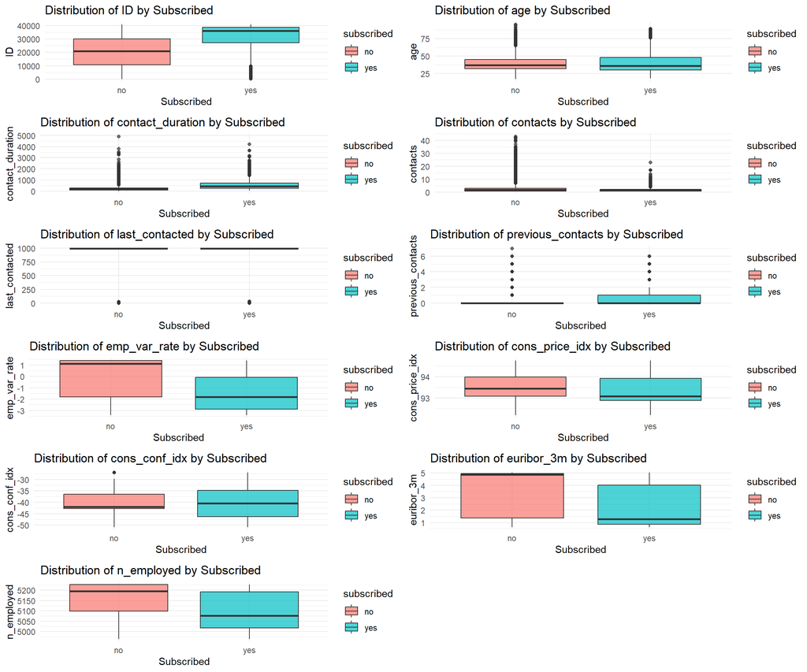

```r
numeric_vars <- data %>% select(where(is.numeric)) %>% names()

numeric_plots <- map(numeric_vars, function(var) {
  data %>%
    ggplot(aes(x = subscribed, y = .data[[var]], fill = subscribed)) +
    geom_boxplot(alpha = 0.7) +
    labs(title = paste("Distribution of", var, "by Subscribed"),
         x = "Subscribed",
         y = var) +
    theme_minimal()
})
numeric_plot_grid <- do.call(grid.arrange, c(numeric_plots, ncol = 2))
```

**Age:** Percentage distribution by age group was almost comparable for the two groups with slightly a higher percentage of people in the older age group in the subscriber category.

**Contact Duration:** The results also show that subscribers have more extended contact period than non-subscribers.

**Last Contacted:** The distribution of the last contacted date is equal in both groups.

**Consumer Price Index:** The frequency distribution of the consumer price index is also almost equal between the two groups.

**Consumer Confidence Index:** As to the distribution of the consumer confidence index, no significant differences between the two groups of respondents were revealed.

## Dealing with Outliers

Outlier removal using the cap method.

```r
cap_outliers <- function(x) {
  qnt <- quantile(x, probs = c(0.25, 0.75), na.rm = TRUE)
  caps <- quantile(x, probs = c(0.01, 0.99), na.rm = TRUE)
  H <- 1.5 * IQR(x, na.rm = TRUE)
  x[x < (qnt[1] - H)] <- caps[1]
  x[x > (qnt[2] + H)] <- caps[2]
  return(x)
}
```

```r
data$age <- cap_outliers(data$age)
data$previous_contacts <- cap_outliers(data$previous_contacts)
data$contact_duration <- cap_outliers(data$contact_duration)
data$contacts <- cap_outliers(data$contacts)
data$last_contacted <- cap_outliers(data$last_contacted)
```

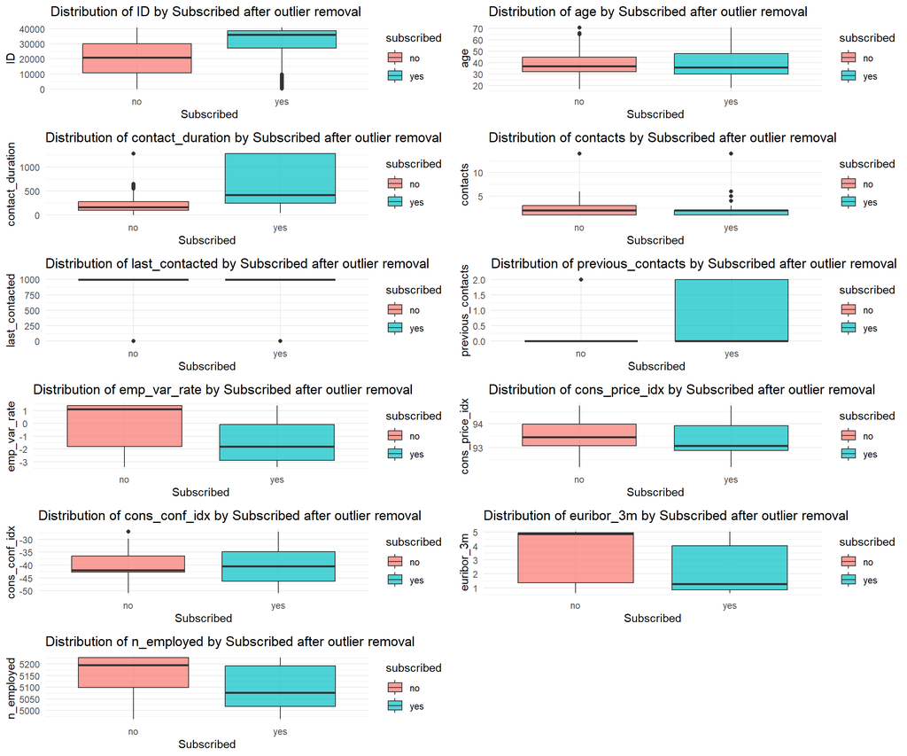

```r
numeric_vars <- data %>% select(where(is.numeric)) %>% names()

numeric_plots <- map(numeric_vars, function(var) {
  data %>%
    ggplot(aes(x = subscribed, y = .data[[var]], fill = subscribed)) +
    geom_boxplot(alpha = 0.7) +
    labs(title = paste("Distribution of", var, "by Subscribed after outlier removal"),
         x = "Subscribed",
         y = var) +
    theme_minimal()
})
numeric_plot_grid <- do.call(grid.arrange, c(numeric_plots, ncol = 2))
```

Relationship of the categorical variables with target variables subscribed

```r
categorical_vars <- data %>% select(where(is.factor)) %>% names()

categorical_plots <- map(categorical_vars, function(var) {
  data %>%
    count(.data[[var]], subscribed) %>%
    ggplot(aes(x = .data[[var]], y = n, fill = subscribed)) +
    geom_bar(stat = "identity", position = "dodge", alpha = 0.8) +
    labs(title = paste("Distribution of", var, "by Subscribed"),
         x = var,
         y = "Count") +
    theme_minimal() +
    theme(axis.text.x = element_text(angle = 45, hjust = 1))
})
```

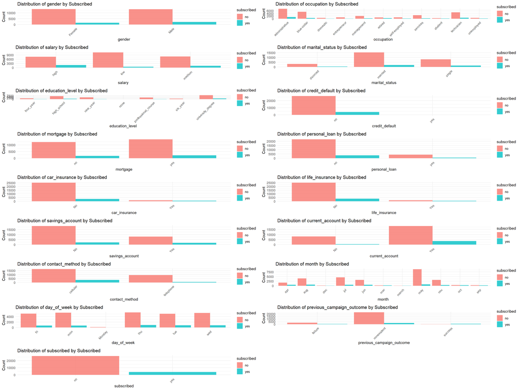

```r
categorical_plot_grid <- do.call(grid.arrange, c(categorical_plots, ncol = 2))
```

**Gender:** There isn’t much difference in gender distribution between viewers who subscribed to Outflex and viewers who do not.

**Occupation:** One can see great differences within occupation patterns. A number of occupations seem to feature more on the list of subscribers than others.

**Salary:** There also appears to be a difference in the proportion between contents of each salary group among the two groups. Subscribers may be located within specific ranges of salary.

**Marital Status:** Marital status distribution also indicates some differences between subscribers and non-subscribers.

**Education Level:** Within the education level group there is variation observed between the two groups. It is possible to identify some education levels as the subscribers’ priorities.

**Credit Default:** From the above, one has a feeling that credit default status is distributed differently between subscribers and non-subscribers.

**Car Insurance:** Car insurance which is compulsory in some countries might be split by subscription status.

**Life Insurance:** The analysis reveals some differences in the results concerning life insurance status between subscribers and non-subscribers.

**Savings Account:** There is an indication that the coming of a savings account can determine the subscription status.

**Current Account**: Now subscription might be related to the current account status.

**Contact Method:** However, it appears that the contact method of choice varies between those subscribers and non-subscribers.

**Month:** The contact months in both the groups are not exactly similar with little variation present.

**Previous Campaign Outcome:** Evaluation of the previous campaigns indicates that, subscription status appears be a factor of the campaigns.

Replacing the unknown categories with NA value and then removing these values.

## Correlation Matrix

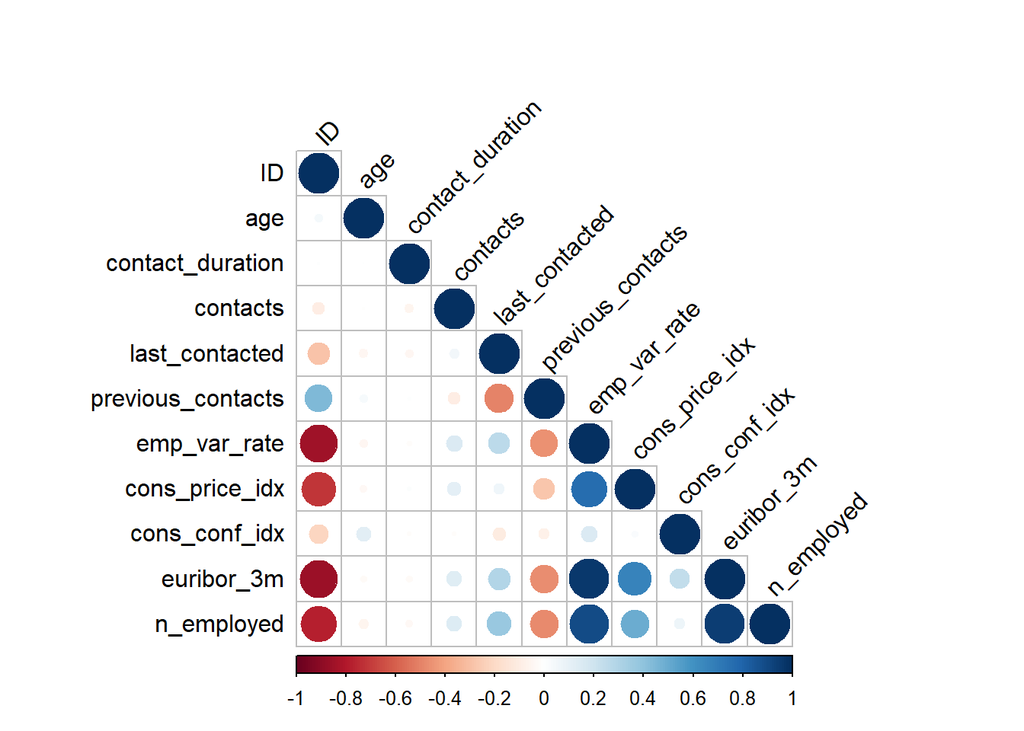

```r
numeric_vars <- data %>% select_if(is.numeric)
cor_matrix <- cor(numeric_vars, use = "complete.obs")
corrplot(cor_matrix, method = "circle", type = "lower", tl.col = "black", tl.srt = 45)
```

```r
head(cor_matrix)
```

```
##                            ID          age contact_duration     contacts
## ID                 1.00000000  0.043649318      0.004329200 -0.091343572
## age                0.04364932  1.000000000      0.001909655 -0.005341391
## contact_duration   0.00432920  0.001909655      1.000000000 -0.053163145
## contacts          -0.09134357 -0.005341391     -0.053163145  1.000000000
## last_contacted    -0.28627727 -0.047235946     -0.046585598  0.056647049
## previous_contacts  0.44438518  0.039623357      0.008734885 -0.090218402
##                   last_contacted previous_contacts emp_var_rate cons_price_idx
## ID                   -0.28627727       0.444385176  -0.84323821    -0.71376419
## age                  -0.04723595       0.039623357  -0.04309761    -0.03287175
## contact_duration     -0.04658560       0.008734885  -0.01940161     0.01363871
## contacts              0.05664705      -0.090218402   0.15320640     0.11242885
## last_contacted        1.00000000      -0.499164616   0.26829821     0.06799131
## previous_contacts    -0.49916462       1.000000000  -0.45278459    -0.27952601
##                   cons_conf_idx  euribor_3m  n_employed
## ID                  -0.21300689 -0.85857675 -0.77713748
## age                  0.12529799 -0.02846428 -0.05561407
## contact_duration    -0.01349726 -0.02607356 -0.03618069
## contacts            -0.01141713  0.13512381  0.14514097
## last_contacted      -0.10360323  0.29485128  0.37074930
## previous_contacts   -0.07180410 -0.46960826 -0.47692758
```

```r
data <- data %>%
  mutate(across(.cols = everything(),
                .fns = ~replace(., . == "unknown", NA)))

colSums(is.na(data))
```

```
##                        ID                       age                    gender
##                         0                         0                         0
##                occupation                    salary            marital_status
##                         0                         0                         0
##           education_level            credit_default                  mortgage
##                         0                         0                         0
##             personal_loan             car_insurance            life_insurance
##                         0                         0                         0
##           savings_account           current_account               credit_card
##                         0                         0                         0
##            contact_method                     month               day_of_week
##                         0                         0                         0
##          contact_duration                  contacts            last_contacted
##                         0                         0                         0
##         previous_contacts previous_campaign_outcome              emp_var_rate
##                         0                         0                         0
##            cons_price_idx             cons_conf_idx                euribor_3m
##                         0                         0                         0
##                n_employed                subscribed
##                         0                         0
```

Removing the features that has strong correlation with target variable and also those that are ir-relevant to the target variable.

## Again checking data quality after outlier removal

```r
data <- data %>%
  select(-c(contacts,ID, previous_campaign_outcome, day_of_week,contact_duration, month)) %>%
  drop_na()
```

```r
sum(duplicated(data))
```

```
## [1] 136
```

```r
data <- data[!duplicated(data), ]
```

We will also verify whether there are any features which come close to being constant. They should be stripped off since they don’t help with content and are unnecessary during model construction. This is the last data after applying the cleaning process.

```r
data <- data[, -nearZeroVar(data)]
data
```

```
## # A tibble: 30,190 × 21
##      age gender occupation     salary marital_status education_level    mortgage
##    <dbl> <fct>  <fct>          <fct>  <fct>          <fct>              <fct>
##  1    56 Male   domestic       low    married        four_year          no
##  2    37 Female services       medium married        high_school        yes
##  3    40 Female administrative low    married        six_year           no
##  4    56 Male   services       high   married        high_school        no
##  5    59 Male   administrative high   married        professional_cour… no
##  6    24 Female technician     low    single         professional_cour… yes
##  7    25 Male   services       medium single         high_school        yes
##  8    25 Male   services       low    single         high_school        yes
##  9    29 Female blue-collar    medium single         high_school        no
## 10    57 Male   domestic       low    divorced       four_year          yes
## # ℹ 30,180 more rows
## # ℹ 14 more variables: personal_loan <fct>, car_insurance <fct>,
## #   life_insurance <fct>, savings_account <fct>, current_account <fct>,
## #   credit_card <chr>, contact_method <fct>, previous_contacts <dbl>,
## #   emp_var_rate <dbl>, cons_price_idx <dbl>, cons_conf_idx <dbl>,
## #   euribor_3m <dbl>, n_employed <dbl>, subscribed <fct>
```

**Checking the class imbalance**

Benefits of having a class imbalance lies on the aspect that privides more focused attention on the minority class when constructing the model, it is highly relevant in the real application of the model as such classes are rare. This paper showed that imbalanced data can be fixed in such a way that both classes can be modeled to be predicted accurately thus enhancing fairness. One way learning from downsampling is that by bringing down the number of samples in major class, the model can be able to pay much attention on the minor class due to the existence of imbalanced classes. This technique can enhance the performance and accuracy of the model as it shall avoid cases whereby the model is dominated to mainly predict samples from the dominant class, in this case, Enhance performance and accuracy of the model by avoiding the model to be kept on predicting samples from the largest class.

```r
prop.table(table(data$subscribed))
```

```
##
##        no       yes
## 0.8724743 0.1275257
```

```r
table(data$subscribed)
```

```
##
##    no   yes
## 26340  3850
```

```r
# Separate the majority and minority classes
majority <- data %>% filter(subscribed == "no")
minority <- data %>% filter(subscribed == "yes")

# Downsample the majority class to match the minority class size
set.seed(123)
majority_downsampled <- majority %>% sample_n(nrow(minority))

# Combine the downsampled majority class with the minority class
balanced_data <- bind_rows(majority_downsampled, minority)

# Shuffle the data
balanced_data <- balanced_data %>% sample_frac(1)

# Verify the class distribution
table(balanced_data$subscribed)
```

```
##
##   no  yes
## 3850 3850
```

## Logistic Regression Model with whole data

```r
# Convert the target variable to a binary
balanced_data$subscribed <- ifelse(balanced_data$subscribed == "yes", 1, 0)
```

```r
# Split data into training and test sets
set.seed(123)
split <- sample(1:nrow(balanced_data), size = 0.8 * nrow(balanced_data))
train_data <- balanced_data[split, ]
test_data <- balanced_data[-split, ]
```

```r
# Fit Logistic Regression Model
logit_model <- glm(subscribed ~ ., data = train_data, family = "binomial")

# Summary of the model
summary(logit_model)
```

```
##
## Call:
## glm(formula = subscribed ~ ., family = "binomial", data = train_data)
##
## Coefficients:
##                                      Estimate Std. Error z value Pr(>|z|)
## (Intercept)                        -1.030e+02  2.651e+01  -3.886 0.000102 ***
## age                                 3.447e-03  4.139e-03   0.833 0.404905
## genderMale                          3.483e-01  6.616e-02   5.265 1.40e-07 ***
## occupationblue-collar              -7.009e-02  1.265e-01  -0.554 0.579511
## occupationdomestic                 -7.573e-02  2.421e-01  -0.313 0.754453
## occupationentrepreneur              5.945e-03  1.955e-01   0.030 0.975741
## occupationmanagement                1.670e-01  1.384e-01   1.207 0.227622
## occupationretired                   3.534e-01  1.912e-01   1.849 0.064526 .
## occupationself-employed            -1.632e-01  1.870e-01  -0.873 0.382907
## occupationservices                 -3.544e-02  1.350e-01  -0.262 0.792957
## occupationstudent                   6.157e-01  2.191e-01   2.811 0.004942 **
## occupationtechnician                6.691e-02  1.125e-01   0.595 0.551856
## occupationunemployed                1.490e-01  2.046e-01   0.728 0.466312
## salarylow                          -1.428e+00  8.428e-02 -16.948  < 2e-16 ***
## salarymedium                       -3.802e-01  7.663e-02  -4.961 7.00e-07 ***
## marital_statusmarried              -1.703e-01  1.072e-01  -1.588 0.112258
## marital_statussingle               -5.231e-02  1.223e-01  -0.428 0.668988
## education_levelhigh_school          3.049e-01  1.613e-01   1.890 0.058720 .
## education_levelnine_year            1.555e-01  1.647e-01   0.944 0.345252
## education_levelnone                 1.976e+00  1.237e+00   1.598 0.110026
## education_levelprofessional_course  2.962e-01  1.737e-01   1.705 0.088109 .
## education_levelsix_year             5.598e-01  2.082e-01   2.689 0.007169 **
## education_leveluniversity_degree    3.431e-01  1.627e-01   2.108 0.035004 *
## mortgageyes                         4.596e-02  6.656e-02   0.691 0.489859
## personal_loanyes                   -5.959e-02  9.085e-02  -0.656 0.511851
## car_insuranceYes                    1.647e+00  1.184e-01  13.907  < 2e-16 ***
## life_insuranceYes                   9.730e-01  1.256e-01   7.744 9.63e-15 ***
## savings_accountYes                  6.665e-01  6.829e-02   9.759  < 2e-16 ***
## current_accountYes                  1.329e+00  8.646e-02  15.377  < 2e-16 ***
## credit_cardYes                      5.434e-01  6.721e-02   8.086 6.19e-16 ***
## contact_methodtelephone            -9.667e-01  9.829e-02  -9.835  < 2e-16 ***
## previous_contacts                  -6.228e-02  4.725e-02  -1.318 0.187482
## emp_var_rate                       -8.824e-01  1.149e-01  -7.679 1.60e-14 ***
## cons_price_idx                      1.228e+00  1.740e-01   7.058 1.68e-12 ***
## cons_conf_idx                       5.249e-02  9.946e-03   5.277 1.31e-07 ***
## euribor_3m                          1.758e-01  1.354e-01   1.299 0.194030
## n_employed                         -2.389e-03  2.433e-03  -0.982 0.326134
## ---
## Signif. codes:  0 '***' 0.001 '**' 0.01 '*' 0.05 '.' 0.1 ' ' 1
##
## (Dispersion parameter for binomial family taken to be 1)
##
##     Null deviance: 8539.4  on 6159  degrees of freedom
## Residual deviance: 5685.4  on 6123  degrees of freedom
## AIC: 5759.4
##
## Number of Fisher Scoring iterations: 5
```

Based on customer and economic characteristics, the model of logistic regression was applied to determine the probability of a customer using a term deposit. It also emerged that several predictors were statistically significant, which brought out the nature of the relationship between the variables and the target variable.

Possible consequences of starting salary levels were found to have a negative influence: substantiating the hypothesis that subjects with low and moderate starting salaries are unfavorable for subscription. With regards to education, telecommunications customers with a higher education, including university or high school education were more likely to subscrib.

Banking and other related financial products such as car insurance, life insurance, savings and current account as well as credit cards appeared to have positive correlation coefficients to subscription thus indicating that those with higher number of bank products are most probable to subscribe.

The way of contact was also important; customers reached through the phone have a lower chance of taking up a term deposit. Finally, employment variation rate and consumer price index were found to be significant; negative relationship between employment variation rate and subscription and positive relationship between consumer price index and subscription.

## Model Evaluation

```r
# Predict probabilities on test set
test_pred_prob <- predict(logit_model, newdata = test_data, type = "response")

# Convert probabilities to binary predictions
threshold <- 0.5
test_pred_class <- ifelse(test_pred_prob >= threshold, 1, 0)
```

## RMSE

```r
preds <- predict(logit_model, test_data)
RMSE(preds, test_data$subscribed)
```

```
## [1] 1.670702
```

## Confusion matrix

```r
conf_matrix <- confusionMatrix(
  factor(test_pred_class, levels = c(0, 1)),
  factor(test_data$subscribed, levels = c(0, 1))
)

# Print Confusion Matrix and Accuracy
cat("Confusion Matrix:\n")
```

```
## Confusion Matrix:
```

```r
print(conf_matrix$table)
```

```
##           Reference
## Prediction   0   1
##          0 570 190
##          1 183 597
```

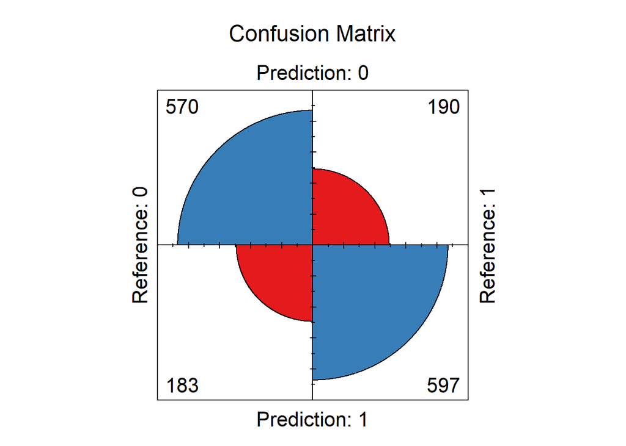

```r
# Plot Confusion Matrix
fourfoldplot(conf_matrix$table,
             color = c("#E41A1C", "#377EB8"),
             conf.level = 0,
             main = "Confusion Matrix")
```

## Accuracy

```r
accuracy <- sum(
  diag(conf_matrix$table)) / sum(conf_matrix$table)
cat("\nAccuracy:", round(accuracy * 100, 2), "%\n")
```

```
##
## Accuracy: 75.78 %
```

## ROC Analysis

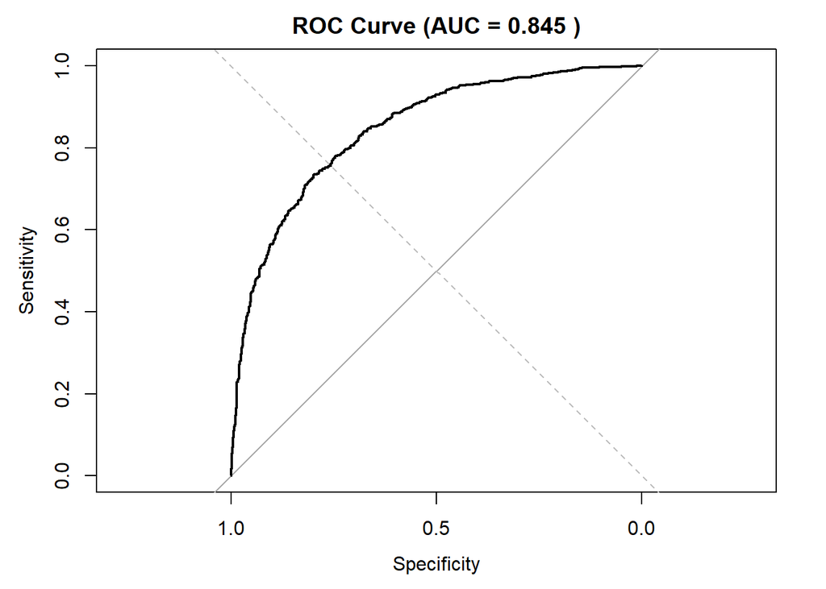

```r
roc_curve <- roc(test_data$subscribed, test_pred_prob)
auc_value <- auc(roc_curve)

# Plot ROC Curve
plot(roc_curve, main = paste("ROC Curve (AUC =", round(auc_value, 3), ")"))
abline(a = 0, b = 1, lty = 2, col = "gray")
```

The ROC curve suggests that the model has reasonable performance in distinguishing between the two classes. The AUC value indicates good discrimination ability, and the shape of the curve suggests that the model is generally able to separate the classes effectively.

## Hypothesis setting based on correlation

Excludig the id column as it is unnecessary information. Now extracting the numerical variables based on the correlation and p value of categorical variables.

```r
data$subscribed <- ifelse(data$subscribed == "yes", 1, 0)

# Separate numerical and categorical variables
numerical_vars <- data %>% select_if(is.numeric)
categorical_vars <- data %>% select_if(is.factor)
```

```r
numerical_correlations <- cor(numerical_vars, use = "complete.obs", method = "pearson")
```

```r
chi_sq_results <- sapply(categorical_vars, function(x) {
  if (n_distinct(x) > 1) {
    chisq.test(table(x, data$subscribed))$p.value
  } else {
    NA
  }
})
chi_sq_results
```

```
##          gender      occupation          salary  marital_status education_level
##    2.486923e-29   7.648255e-149   1.118387e-214    1.434567e-12    1.498232e-23
##        mortgage   personal_loan   car_insurance  life_insurance savings_account
##    7.195129e-02    4.213386e-01   7.252259e-260    8.375050e-64    2.116387e-85
## current_account  contact_method
##   2.074400e-141   4.563793e-141
```

```r
chi_sq_results_df <- data.frame(
  Variable = names(chi_sq_results),
  Chi_Square_P_Value = chi_sq_results
) %>% drop_na()

chi_sq_results_df
```

```
##                        Variable Chi_Square_P_Value
## gender                   gender       2.486923e-29
## occupation           occupation      7.648255e-149
## salary                   salary      1.118387e-214
## marital_status   marital_status       1.434567e-12
## education_level education_level       1.498232e-23
## mortgage               mortgage       7.195129e-02
## personal_loan     personal_loan       4.213386e-01
## car_insurance     car_insurance      7.252259e-260
## life_insurance   life_insurance       8.375050e-64
## savings_account savings_account       2.116387e-85
## current_account current_account      2.074400e-141
## contact_method   contact_method      4.563793e-141
```

```r
# Set thresholds for high correlation and significant Chi-Square association
cor_threshold <- 0.5
p_value_threshold <- 0.05

# Select highly correlated numerical variables
high_corr_numerical_vars <- colnames(numerical_vars)[
  apply(numerical_correlations, 2, function(x) any(abs(x) > cor_threshold))
]
```

```r
significant_categorical_vars <- chi_sq_results_df %>%
  filter(Chi_Square_P_Value < p_value_threshold) %>%
  pull(Variable)

# Combine selected variables
selected_variables <- c(high_corr_numerical_vars, significant_categorical_vars)
```

```r
Hypothesis_2 <- data %>% select(all_of(selected_variables))
```

```r
print("Selected Numerical Variables:")
```

```
## [1] "Selected Numerical Variables:"
```

```r
print(high_corr_numerical_vars)
```

```
## [1] "age"               "previous_contacts" "emp_var_rate"
## [4] "cons_price_idx"    "cons_conf_idx"     "euribor_3m"
## [7] "n_employed"        "subscribed"
```

```r
print("Selected Categorical Variables:")
```

```
## [1] "Selected Categorical Variables:"
```

```r
print(significant_categorical_vars)
```

```
##  [1] "gender"          "occupation"      "salary"          "marital_status"
##  [5] "education_level" "car_insurance"   "life_insurance"  "savings_account"
##  [9] "current_account" "contact_method"
```

```r
print("Subset Dataset for Hypothesis Testing:")
```

```
## [1] "Subset Dataset for Hypothesis Testing:"
```

```r
head(Hypothesis_2)
```

```
## # A tibble: 6 × 18
##     age previous_contacts emp_var_rate cons_price_idx cons_conf_idx euribor_3m
##   <dbl>             <dbl>        <dbl>          <dbl>         <dbl>      <dbl>
## 1    56                 0          1.1           94.0         -36.4       4.86
## 2    37                 0          1.1           94.0         -36.4       4.86
## 3    40                 0          1.1           94.0         -36.4       4.86
## 4    56                 0          1.1           94.0         -36.4       4.86
## 5    59                 0          1.1           94.0         -36.4       4.86
## 6    24                 0          1.1           94.0         -36.4       4.86
## # ℹ 12 more variables: n_employed <dbl>, subscribed <dbl>, gender <fct>,
## #   occupation <fct>, salary <fct>, marital_status <fct>,
## #   education_level <fct>, car_insurance <fct>, life_insurance <fct>,
## #   savings_account <fct>, current_account <fct>, contact_method <fct>
```

using this hypothesis to build the regression models.

```r
selected_data <- data %>%
  select(all_of(selected_variables), subscribed)
```

### Splitting data

```r
set.seed(123)
train_index <- createDataPartition(selected_data$subscribed, p = 0.8, list = FALSE)
train_data <- selected_data[train_index, ]
test_data <- selected_data[-train_index, ]
```

```r
# Separate predictors and target
x_train <- train_data %>% select(-subscribed)
y_train <- train_data$subscribed
x_test <- test_data %>% select(-subscribed)
y_test <- test_data$subscribed
```

## Linear Regression Model

```r
linear_model <- lm(subscribed ~ ., data = train_data)
linear_model
```

```
##
## Call:
## lm(formula = subscribed ~ ., data = train_data)
##
## Coefficients:
##                        (Intercept)                                 age
##                         -1.258e+01                           3.793e-04
##                  previous_contacts                        emp_var_rate
##                          5.048e-03                          -9.694e-02
##                     cons_price_idx                       cons_conf_idx
##                          1.775e-01                           8.469e-03
##                         euribor_3m                          n_employed
##                          2.967e-02                          -7.210e-04
##                         genderMale               occupationblue-collar
##                          3.498e-02                          -1.498e-02
##                 occupationdomestic              occupationentrepreneur
##                          2.499e-03                          -2.123e-02
##               occupationmanagement                   occupationretired
##                         -5.340e-03                           3.864e-02
##            occupationself-employed                  occupationservices
##                          5.716e-03                          -1.641e-02
##                  occupationstudent                occupationtechnician
##                          6.909e-02                           4.730e-03
##               occupationunemployed                           salarylow
##                          1.072e-02                          -1.128e-01
##                       salarymedium               marital_statusmarried
##                         -4.450e-02                           5.618e-03
##               marital_statussingle          education_levelhigh_school
##                          1.080e-02                           1.087e-02
##           education_levelnine_year                 education_levelnone
##                         -3.315e-03                           1.641e-01
## education_levelprofessional_course             education_levelsix_year
##                          1.035e-02                           1.233e-02
##   education_leveluniversity_degree                    car_insuranceYes
##                          2.320e-02                           2.108e-01
##                  life_insuranceYes                  savings_accountYes
##                          1.061e-01                           6.467e-02
##                 current_accountYes             contact_methodtelephone
##                          8.913e-02                          -1.150e-01
```

The use of regression model gives an understanding on factors likely to affect subscription. Some of these are previous contacts, cons_price_idx and euribor_3m which have values that increase the probability of subscription when higher. Notably, gender (Male) and the current account or car insurance holders are more inclined to subscribe. On the other hand, negative relation with emp_var_rate and salary (low or medium categories) mean these factors reduce subscription probability. As for categorical coefficients, employment status with those who have never worked, students, and retired individuals have a higher probability of subscription, although blue-collar workers and entrepreneurs have a lower probability of subscription. Further, university education and life insurance subscription are also positively related with subscriptions. In sum, this model sheds light on how demographic, financial and behavioiral factors interact in regard to the output.

```r
linear_preds <- predict(linear_model, newdata = test_data)
rmse_linear <- RMSE(linear_preds, y_test)
```

## Ridge Regression Model

```r
ridge_model <- cv.glmnet(as.matrix(x_train), y_train, alpha = 0)
ridge_model
```

```
##
## Call:  cv.glmnet(x = as.matrix(x_train), y = y_train, alpha = 0)
##
## Measure: Mean-Squared Error
##
##      Lambda Index Measure       SE Nonzero
## min 0.01222   100 0.09721 0.001105       7
## 1se 0.13729    74 0.09820 0.001045       7
```

1-SE Rule ( 𝜆 1se ): At 𝜆 = 0.13729 (index 74), the MSE =0.09820 and the SE =0.001045. This value of 𝜆 λ is chosen based on the 1-SE rule which works better than cross-validation by providing a simpler model which generalizes better but has slightly higher error. Like the 𝜆 min λ min  According to the configuration of predetermined parameters within this model, this configuration also holds 7 non-zero coefficients.

```r
ridge_preds <- predict(ridge_model, as.matrix(x_test), s = "lambda.min")
rmse_ridge <- RMSE(ridge_preds, y_test)
```

## Lasso Regression Model

```r
lasso_model <- cv.glmnet(as.matrix(x_train), y_train, alpha = 1)
lasso_model
```

```
##
## Call:  cv.glmnet(x = as.matrix(x_train), y = y_train, alpha = 1)
##
## Measure: Mean-Squared Error
##
##       Lambda Index Measure       SE Nonzero
## min 0.000045    86 0.09712 0.001740       7
## 1se 0.022901    19 0.09879 0.001874       2
```

Cross validation results of Lasso Regression Model reveals here: 𝛼 = 1) in order to demonstrate the performance of the model. λ):

Minimum MSE ( 𝜆 min  ): At 𝜆 = 0.000045 or index 86), then the MSE reduced to 0.09712 + SE of 0.001740. At this stage the model keeps 7 non zero coefficients imply that 7 of the predictor random variables influence the prediction.

1-SE Rule ( 𝜆 1se  ): At 𝜆 = 0.022901 When λ = 0.022901 which corresponds to an index 19, the MSE has a slight rise and reaches 0.09879 with the SE of 0.001874. Under this configuration, the flow of funds model is simplified to keep only 2 non-zero coefficients. This is in concordance with the 1-SE rule, because the objective here is to choose a model with a fewer number of predictors but makes a little more error which is better for purposes of giving a general estimate.

```r
lasso_preds <- predict(lasso_model, as.matrix(x_test), s = "lambda.min")
rmse_lasso <- RMSE(lasso_preds, y_test)
```

```r
rmse_results <- data.frame(
  Model = c("Linear Regression", "Ridge Regression", "Lasso Regression"),
  RMSE = c(rmse_linear, rmse_ridge, rmse_lasso )
)
print(rmse_results)
```

```
##               Model      RMSE
## 1 Linear Regression 0.2790649
## 2  Ridge Regression 0.2953297
## 3  Lasso Regression 0.2952278
```

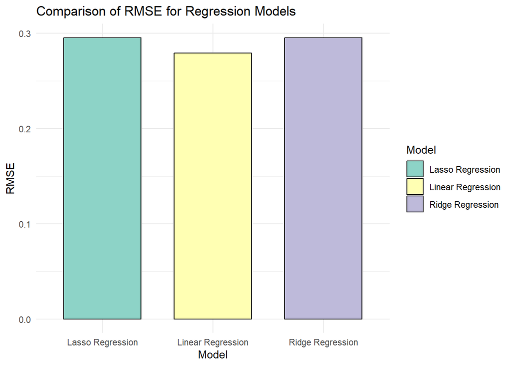

```r
ggplot(rmse_results, aes(x = Model, y = RMSE, fill = Model)) +
  geom_bar(stat = "identity", color = "black", width = 0.7) +
  theme_minimal() +
  labs(title = "Comparison of RMSE for Regression Models", y = "RMSE", x = "Model") +
  scale_fill_brewer(palette = "Set3")
```

**Linear Regression (RMSE = 0.2791)**: This model achieves the lowest RMSE, indicating that it has the highest prediction accuracy among the three. However, it does not account for potential multicollinearity or overfitting, as no regularization is applied.

**Ridge Regression (RMSE = 0.2953)**: The slightly higher RMSE reflects a trade-off between prediction accuracy and the benefits of regularization. Ridge Regression shrinks the coefficients to reduce the impact of multicollinearity and overfitting, which can improve model robustness on unseen data.

**Lasso Regression (RMSE = 0.2952)**: Lasso achieves an RMSE very close to Ridge Regression. In addition to regularization, Lasso performs feature selection by setting some coefficients to zero. This can result in a simpler and more interpretable model, especially useful when some predictors are less significant.

## MultiColinearity check

```r
vif_results <- vif(linear_model)
print("Multi-Colinearity by Variance Inflation Factor (VIF) for Linear Regression:")
```

```
## [1] "Multi-Colinearity by Variance Inflation Factor (VIF) for Linear Regression:"
```

```r
print(vif_results)
```

```
##                        GVIF Df GVIF^(1/(2*Df))
## age                1.649121  1        1.284181
## previous_contacts  1.319106  1        1.148523
## emp_var_rate      36.939578  1        6.077794
## cons_price_idx     9.457810  1        3.075355
## cons_conf_idx      2.765250  1        1.662904
## euribor_3m        63.028284  1        7.939035
## n_employed        33.848580  1        5.817953
## gender             1.002616  1        1.001307
## occupation         4.317069 10        1.075869
## salary             1.011586  2        1.002884
## marital_status     1.314819  2        1.070820
## education_level    3.068534  6        1.097937
## car_insurance      1.010755  1        1.005363
## life_insurance     1.003754  1        1.001875
## savings_account    1.004756  1        1.002375
## current_account    1.004674  1        1.002334
## contact_method     1.882986  1        1.372219
```

## Five Linear Models

```r
models <- list(
  lm_1 = lm(subscribed ~ age + emp_var_rate + euribor_3m, data = train_data),
  lm_2 = lm(subscribed ~ previous_contacts + cons_price_idx + n_employed, data = train_data),
  lm_3 = lm(subscribed ~ gender + marital_status + education_level, data = train_data),
  lm_4 = lm(subscribed ~ salary + car_insurance + life_insurance, data = train_data),
  lm_5 = lm(subscribed ~ savings_account + current_account + contact_method, data = train_data)
)
```

```r
# Fit and summarize each model
model_summaries <- lapply(models, summary)

# Print summaries for all models
for (i in seq_along(models)) {
  cat("\nModel", i, "Summary:\n")
  print(model_summaries[[i]])
}
```

```
##
## Model 1 Summary:
##
## Call:
## lm(formula = subscribed ~ age + emp_var_rate + euribor_3m, data = train_data)
##
## Residuals:
##      Min       1Q   Median       3Q      Max
## -0.33897 -0.24363 -0.04964 -0.03348  0.98208
##
## Coefficients:
##                Estimate Std. Error t value Pr(>|t|)
## (Intercept)   0.3040474  0.0181288  16.772  < 2e-16 ***
## age           0.0011802  0.0002046   5.767 8.15e-09 ***
## emp_var_rate  0.0046616  0.0051803   0.900    0.368
## euribor_3m   -0.0636401  0.0046933 -13.560  < 2e-16 ***
## ---
## Signif. codes:  0 '***' 0.001 '**' 0.01 '*' 0.05 '.' 0.1 ' ' 1
##
## Residual standard error: 0.3193 on 24148 degrees of freedom
## Multiple R-squared:  0.1009, Adjusted R-squared:  0.1008
## F-statistic: 903.4 on 3 and 24148 DF,  p-value: < 2.2e-16
##
##
## Model 2 Summary:
##
## Call:
## lm(formula = subscribed ~ previous_contacts + cons_price_idx +
##     n_employed, data = train_data)
##
## Residuals:
##      Min       1Q   Median       3Q      Max
## -0.53242 -0.20831 -0.05400 -0.02501  0.99236
##
## Coefficients:
##                     Estimate Std. Error t value Pr(>|t|)
## (Intercept)        5.534e+00  3.345e-01  16.542  < 2e-16 ***
## previous_contacts  1.171e-02  3.168e-03   3.696 0.000219 ***
## cons_price_idx     3.665e-02  3.941e-03   9.300  < 2e-16 ***
## n_employed        -1.712e-03  3.363e-05 -50.919  < 2e-16 ***
```

[output cut: 70 more lines]

```
##      Min       1Q   Median       3Q      Max
## -0.24926 -0.16764 -0.14120 -0.05958  1.04110
##
## Coefficients:
##                          Estimate Std. Error t value Pr(>|t|)
## (Intercept)              0.059584   0.004518   13.19   <2e-16 ***
## savings_accountYes       0.081620   0.004520   18.06   <2e-16 ***
## current_accountYes       0.108060   0.004712   22.93   <2e-16 ***
## contact_methodtelephone -0.100681   0.004473  -22.51   <2e-16 ***
## ---
## Signif. codes:  0 '***' 0.001 '**' 0.01 '*' 0.05 '.' 0.1 ' ' 1
##
## Residual standard error: 0.3274 on 24148 degrees of freedom
## Multiple R-squared:  0.05495,    Adjusted R-squared:  0.05484
## F-statistic: 468.1 on 3 and 24148 DF,  p-value: < 2.2e-16
```

```r
calculate_rmse <- function(model, data) {
  predictions <- predict(model, newdata = data)
  actuals <- data$subscribed
  sqrt(mean((predictions - actuals)^2))
}
```

```r
rmse_values <- sapply(models, calculate_rmse, data = test_data)


rmse_df <- data.frame(
  Model = paste0("Model_", seq_along(rmse_values)),
  RMSE = rmse_values
)

# Print RMSE values
print(rmse_df)
```

```
##        Model      RMSE
## lm_1 Model_1 0.3044565
## lm_2 Model_2 0.2975104
## lm_3 Model_3 0.3197377
## lm_4 Model_4 0.3091766
## lm_5 Model_5 0.3128068
```

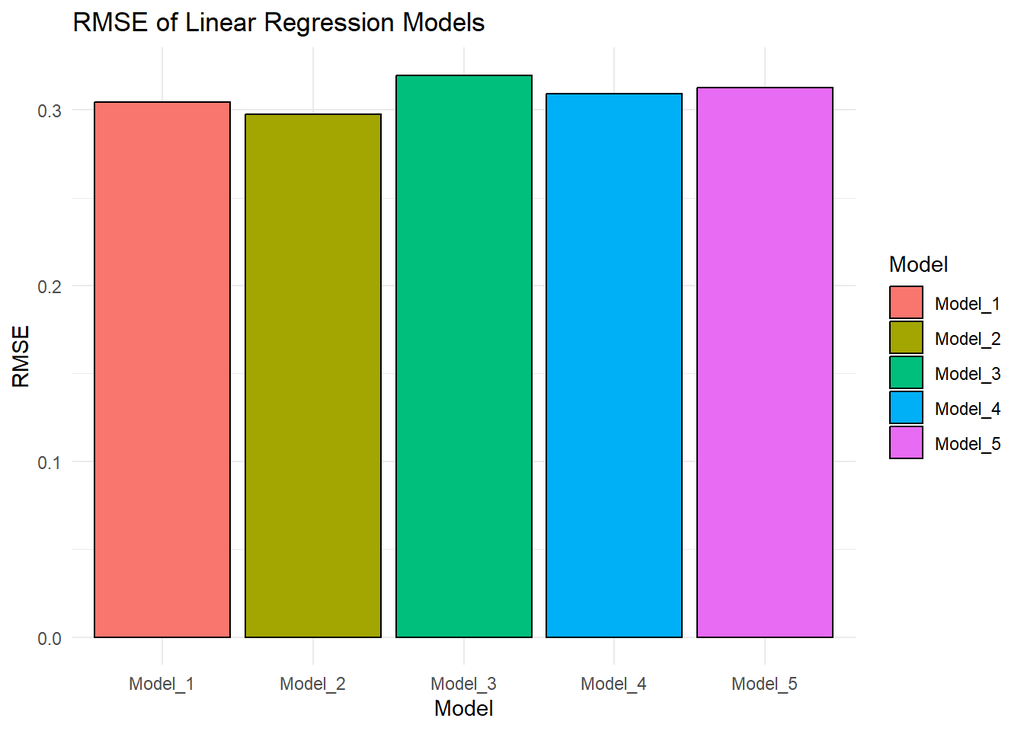

```r
ggplot(rmse_df, aes(x = Model, y = RMSE, fill = Model)) +
  geom_bar(stat = "identity", color = "black") +
  labs(title = "RMSE of Linear Regression Models", x = "Model", y = "RMSE") +
  theme_minimal()
```